# pulse_rate_starter

### Project Write-up

**Code Description**

Below are the required libraries to run this Pulse Rate Algorithm:

- glob
- numpy
- scipy
- matplotlib (Used to compute spectogram)

This notebook demonstrate a Pulse Rate Algorithm. You can run the `Evaluate` function to compute statistics of an aggregate error metric of the estimated pulse rate of this Pulse Rate Algorithm using the the **Troika**[1] dataset.

When the `Evaluate` function is called, it will pass each dataset and its reference pulse rate dataset to the `RunPulseRateAlgorithm` which returns a 2-tuple of an array of absolute error between the estimated and reference pulse rate, and a confidence value of each time window - Note that those time windows are aligned with samples used in the reference dataset. A list of this tuple will be used to computed an aggregate error metric in order to evaluate a performance of this algorithm

Below are functions used in the `RunPulseRateAlgorithm` function that are building blocks for our algorithm:

`LoadTroikaDataset`

- Retrieve the .mat filenames for the troika dataset and its reference dataset.
- The data and reference datasets are ordered correspondingly

`LoadTroikaDataFile`

- Loads and extracts ppg, accx, accy, accz signals from a 2-tuple of troika data file and its reference data.

`AggregateErrorMetric`

- This function is used in the `Evaluate` function to compute an aggregate error metric (MAE) based on confidence estimates at 90% availability.
- This is done by
  1. From a list of confidence values for each time window, retrieve the confidence values that are above the 10th percentile confidence
  2. Retrieve a list of corresponding absolute error values of the filtered confidence values above
  3. Compute and return the the mean value of a list of interested absolute error values above and

`BandpassFilter`

`get_spectogram_data`

- Compute spectogram data (FFT) of each time window (8-second each with 6 seconds overlapped between two successive time windows) for ppg, accx, accy, accz, and aggregated accelerometer signals
- The `specgram` function in the matplotlib is used to achieve this task

`get_freq_peaks`

- Compute peaks of a given spectogram data
- The `scipy.signal.find_peaks` is used to find peaks between 0-5 Hz using a given spectogram data. A criteria of the peaks is that its height must be greater than 10% of the maximum absolute spectogram value

**Data Description**

We are using the **Troika**[1] dataset to build this algorithm - There are 12 datasets used to evaluate our Pulse Rate Algorithm.

Each dataset file include Two-channel PPG signals, three-axis acceleration signals, and one-channel ECG signals were simultaneously recorded from subjects with age from 18 to 35. The reference calculated ground-truth heart rate dataset is used to compute an absolute error metric where each data is corresponding to an 8-second time window and two successive time windows are overlapped by 6 seconds.

The datasets are recorded by having each subject ran on a treadmill with changing speeds. There are two running pattern used to collect data in these datasets:

- Type01: the running speeds changed as follows:

  rest(30s) -> 8km/h(1min) -> 15km/h(1min) -> 8km/h(1min) -> 15km/h(1min) -> rest(30s)
- Type02: the running speeds changed as follows:

  rest(30s) -> 6km/h(1min) -> 12km/h(1min) -> 6km/h(1min) -> 12km/h(1min) -> rest(30s)

To build a more complete dataset, we would need data that can capture other types of activities e.g. biking, resting, etc.

**Algorithhm Description**

- This algorithm estimates pulse rate from the PPG signal and a 3-axis accelerometer.
- For the PPG signal, a peak of signals in the frequency domain can come from
  - When the ventricles contract, the capillaries in the wrist fill with blood. The (typically green) light emitted by the PPG sensor is absorbed by red blood cells in these capillaries and the photodetector will see the drop in reflected light. When the blood returns to the heart, fewer red blood cells in the wrist absorb the light and the photodetector sees an increase in reflected light. The period of this oscillating waveform is the pulse rate -> and we use this to phenomenon to compute an estimated heart rate.
  - However, it is possible that the peaks come from other unwanted noise/activities such as hand movements and that is why we need data from the 3-axis accelerometer to compute their dominant frequencies and used them to identify peaks from those other activities in the PPG signal
- It assumes pulse rate will be restricted between 40BPM (beats per minute) and 240BPM
- It produces an output every 2 seconds using a 8-second window
- It produces an estimation confidence. A higher confidence value means that this estimate should be more accurate than an estimate with a lower confidence value
  - This is because the higher confidence value is due to that the PPG sensor detects a peak with a higher energy
- Caveat of this algorithm is when a user loosely put on a wearable and results in a weak PPG signal where our algorithm could miss detecting a peak in the frequency domain that represents a pulse rate

**Algorithm Performance**

This algorithm performance success criteria is that the best 90% of the estimates according to computed confidence output-- must have a mean absolute error of less than 15 BPM.

The output of the `Evaluate` function shows that we can achieve a mean absolute error of around 10 BPM which meets our criteria. This means that, with the top 90% most confident estimates, this algorithm can predict a pulse rate (bpm) using PPG signals with a mean absolute error (MAP) value around 10 bpm.

A caveat for this algorithm is that, since the dataset uses to evaluate our algorithm contains data for a very specific setup (rest->run->slowdown->run->rest), this might not generalize well in general when a user activity is not deterministic and could result in a different heart rate pattern

### Exploratory

Let's take a look at how the ppg and acc signals look like in both Time and Frequence domains

```python
data_fls, ref_fls = LoadTroikaDataset()
```

```python
data_fls
```

```
['./datasets/troika/training_data/DATA_01_TYPE01.mat',
 './datasets/troika/training_data/DATA_02_TYPE02.mat',
 './datasets/troika/training_data/DATA_03_TYPE02.mat',
 './datasets/troika/training_data/DATA_04_TYPE01.mat',
 './datasets/troika/training_data/DATA_04_TYPE02.mat',
 './datasets/troika/training_data/DATA_05_TYPE02.mat',
 './datasets/troika/training_data/DATA_06_TYPE02.mat',
 './datasets/troika/training_data/DATA_07_TYPE02.mat',
 './datasets/troika/training_data/DATA_08_TYPE02.mat',
 './datasets/troika/training_data/DATA_10_TYPE02.mat',
 './datasets/troika/training_data/DATA_11_TYPE02.mat',
 './datasets/troika/training_data/DATA_12_TYPE02.mat']
```

Specifically inspect the first data file

```python
ppg, accx, accy, accz = LoadTroikaDataFile(data_fls[0])
```

```python
data_signals, data_freqs = get_spectogram_data(ppg, accx, accy, accz, fs)
```

```python
ppg_freqs = get_freq_peaks(data_freqs['ppg'])

accx_freqs = get_freq_peaks(data_freqs['accx'])
accy_freqs = get_freq_peaks(data_freqs['accy'])
accz_freqs = get_freq_peaks(data_freqs['accz'])
acc_agg_freqs = get_freq_peaks(data_freqs['acc_agg'])
```

From the generated spectogram, notice that we can restrict our algorithm to find peaks within the first 5 Hz

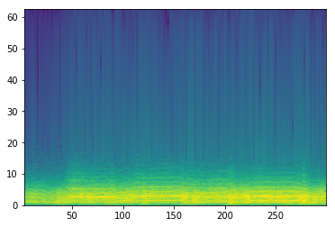

```python
nfft_window = fs*8
noverlap = fs*6

filtered_ppg = BandpassFilter(ppg)
filt_ppg_specs, filt_ppg_freqs,_,_ = plt.specgram(filtered_ppg, NFFT = nfft_window, Fs=fs, noverlap=noverlap)
```

Pick a timeslot and inspect the frequency domain of all signals for the first 5 Hz (around 40 samples).

Observe that our algorithm successfully compute peaks for each signal

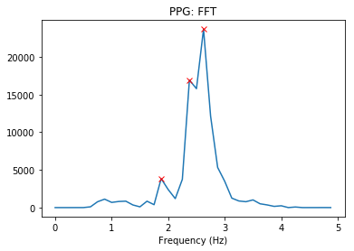

```python
ppg_peak_indice = ppg_freqs[40]['peak_indice']
plt.plot(data_freqs['ppg']['freqs'][:40], data_freqs['ppg']['specs'][:40, 40]);
plt.plot(data_freqs['ppg']['freqs'][ppg_peak_indice], data_freqs['ppg']['specs'][ppg_peak_indice, 40], 'rx');
plt.title('PPG: FFT')
plt.xlabel('Frequency (Hz)');
```

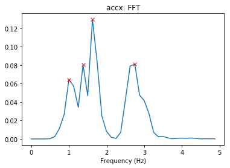

```python
accx_peak_indice = accx_freqs[40]['peak_indice']
plt.plot(data_freqs['accx']['freqs'][:40], data_freqs['accx']['specs'][:40, 40]);
plt.plot(data_freqs['accx']['freqs'][accx_peak_indice], data_freqs['accx']['specs'][accx_peak_indice, 40], 'rx');
plt.title('accx: FFT')
plt.xlabel('Frequency (Hz)');
```

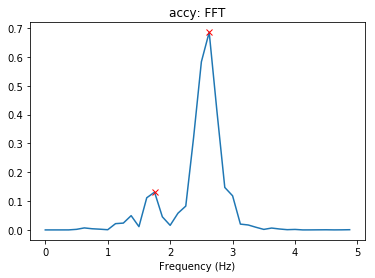

```python
accy_peak_indice = accy_freqs[40]['peak_indice']
plt.plot(data_freqs['accy']['freqs'][:40], data_freqs['accy']['specs'][:40, 40]);
plt.plot(data_freqs['accy']['freqs'][accy_peak_indice], data_freqs['accy']['specs'][accy_peak_indice, 40], 'rx');
plt.title('accy: FFT')
plt.xlabel('Frequency (Hz)');
```

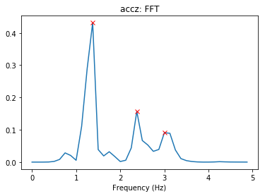

```python
accz_peak_indice = accz_freqs[40]['peak_indice']
plt.plot(data_freqs['accz']['freqs'][:40], data_freqs['accz']['specs'][:40, 40]);
plt.plot(data_freqs['accz']['freqs'][accz_peak_indice], data_freqs['accz']['specs'][accz_peak_indice, 40], 'rx');
plt.title('accz: FFT')
plt.xlabel('Frequency (Hz)');
```

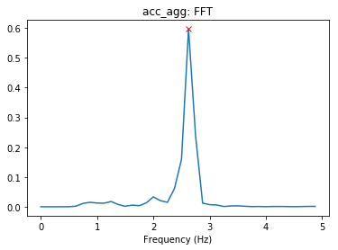

```python
acc_agg_peak_indice = acc_agg_freqs[40]['peak_indice']
plt.plot(data_freqs['acc_agg']['freqs'][:40], data_freqs['acc_agg']['specs'][:40, 40]);
plt.plot(data_freqs['acc_agg']['freqs'][acc_agg_peak_indice], data_freqs['acc_agg']['specs'][acc_agg_peak_indice, 40], 'rx');
plt.title('acc_agg: FFT')
plt.xlabel('Frequency (Hz)');
```

Inspect signals of all data files

```python
def plot_signals(troikaDataFile, fs=125, window_time=None):

    orig_ppg, accx, accy, accz = LoadTroikaDataFile(troikaDataFile)

    accy = accy-np.mean(accy) # Center Y values

    ts_ppg = np.arange(len(orig_ppg)) * (1/fs)
    ts_acc = np.arange(len(accx)) * (1/fs)

    if window_time is not None:

        if window_time[0]:
            sample_start = window_time[0]*fs
        else:
            sample_start = 0

        if ((len(window_time) == 2) and window_time[1]):
            sample_end = window_time[1]*fs + 1
        else:
            sample_end = len(ts_ppg)

        orig_ppg = orig_ppg[sample_start:sample_end]
        accx = accx[sample_start:sample_end]
        accy = accy[sample_start:sample_end]
        accz = accz[sample_start:sample_end]

        ts_ppg = ts_ppg[sample_start:sample_end]
        ts_acc = ts_acc[sample_start:sample_end]

    ppg = BandpassFilter(orig_ppg, fs)

    # Aggregate acc signals from all dimensions
    orig_acc_mag = np.sqrt(accx**2 + accy**2 + accz**2)
    acc_agg = BandpassFilter(orig_acc_mag, fs)

    # --- PPG Signal
    fig = plt.figure(figsize=(12, 8))
    plt.subplot(2,2,1)
    plt.plot(ts_ppg, ppg)
    plt.title('PPG Signal: Time-Domain')
    plt.subplot(2,2,3)

    # From README
    nfft_window = fs*8
    noverlap = fs*6

    filt_ppg_specs, filt_ppg_freqs,_,_ = plt.specgram(ppg, NFFT = nfft_window, Fs=fs, noverlap=noverlap)
    plt.title('Spectogram 0-5Hz')
    plt.xlabel('Time (sec)')
    plt.ylim(0,5)

    # --- Acc Signal
    plt.subplot(2,2,2)
    plt.plot(ts_acc, acc_agg)
    plt.title('Aggregated Accelerometer Signal: Time-Domain')

    plt.subplot(2,2,4)
    filt_acc_specs, filt_acc_freqs,_,_ = plt.specgram(acc_agg, NFFT = nfft_window, Fs=fs, noverlap=noverlap)
    plt.title('Spectogram 0-5Hz')
    plt.xlabel('Time (sec)')
    plt.ylim(0,5)

    fig.suptitle('File: {}'.format(troikaDataFile))
    plt.show()
```

Notice that the spectogram for ppg and aggregated accelerometer signals of each dataset have portions with similar intensity patterns and those likely be the noise frequecy that we can remove when computing an estimated pulse rate

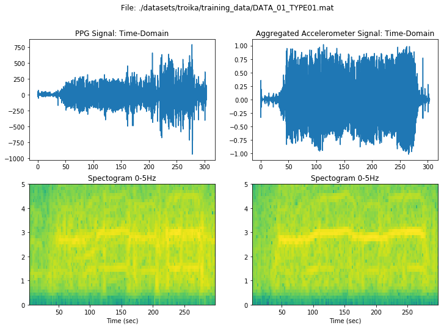

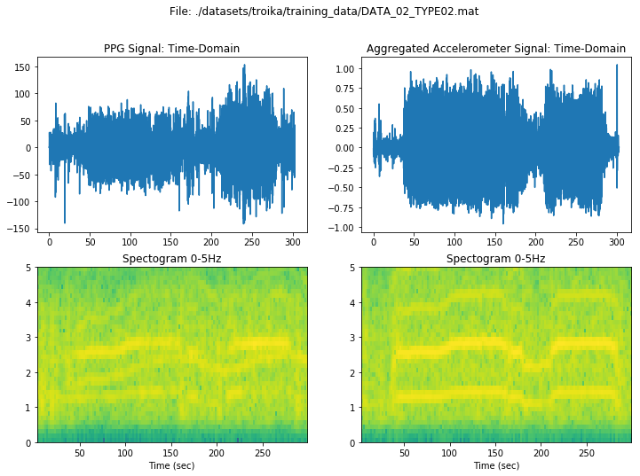

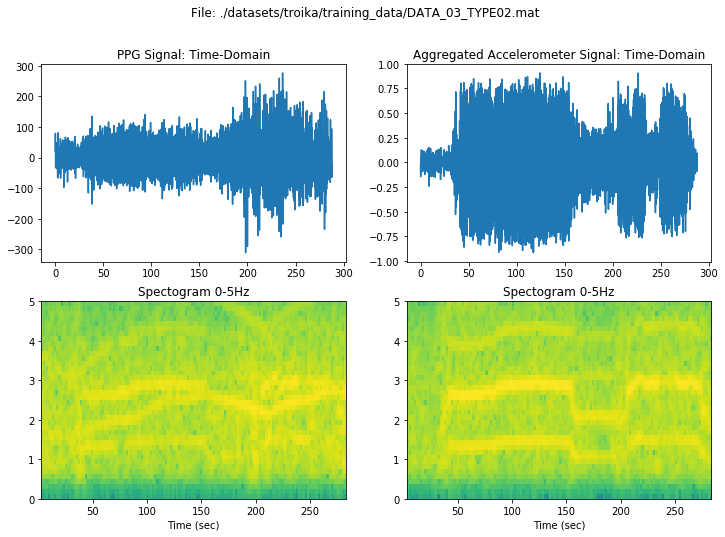

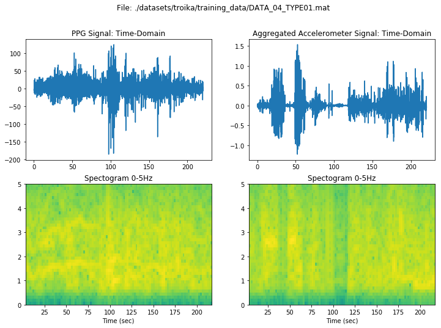

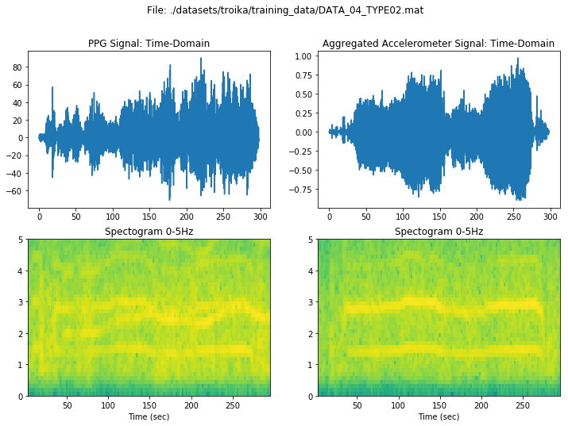

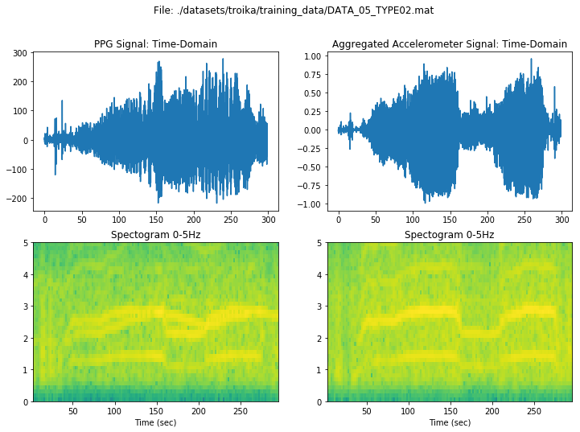

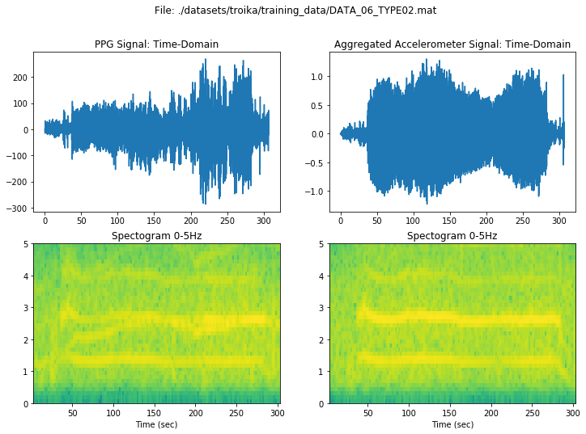

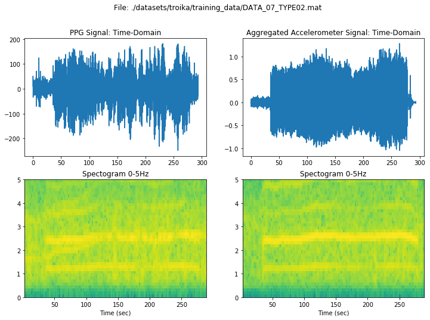

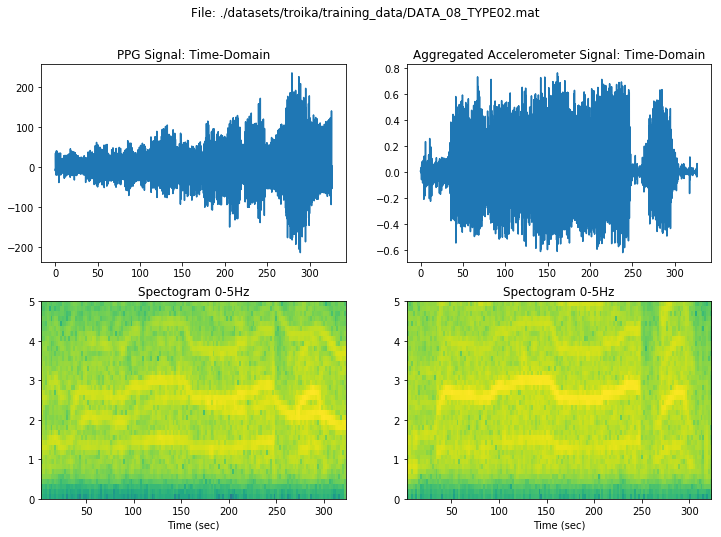

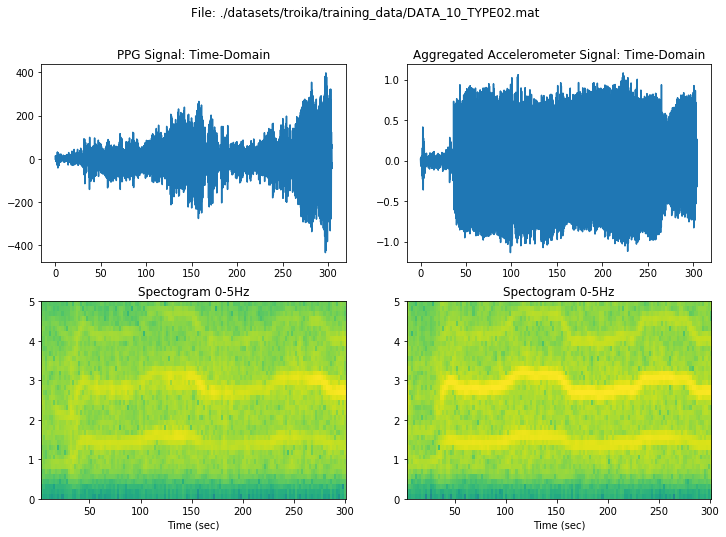

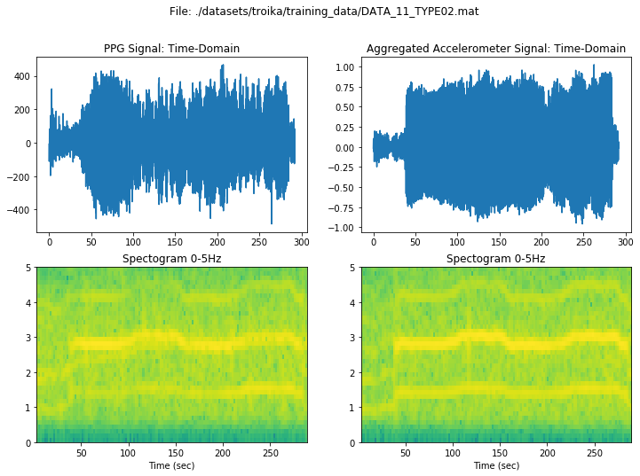

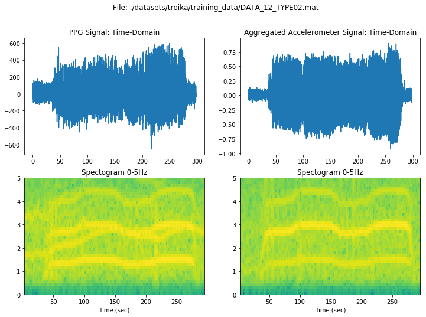

```python
for idx in range(0,len(data_fls)):
    filename = data_fls[idx]

    plot_signals(filename, fs)
```

Let's also inpect ppg and aggregated accelerometer signals for each 60-second time window and inspect their corresponding FFT to see whether we see a similar intensity pattern between both spectograms

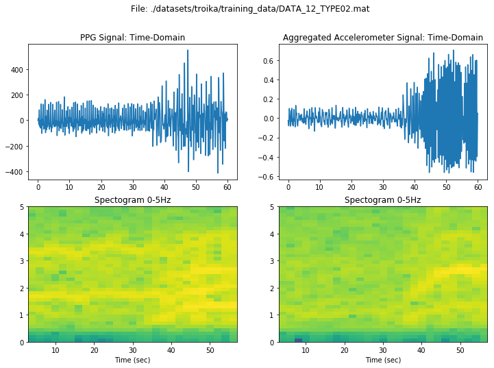

```python
plot_signals(filename, fs, window_time=(0,60))
```

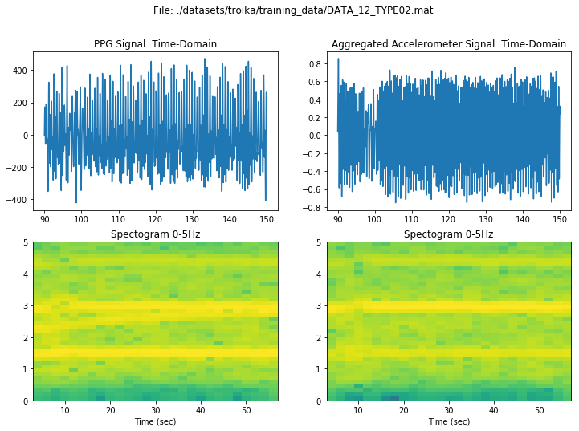

```python
plot_signals(filename, fs, window_time=(90,150))
```

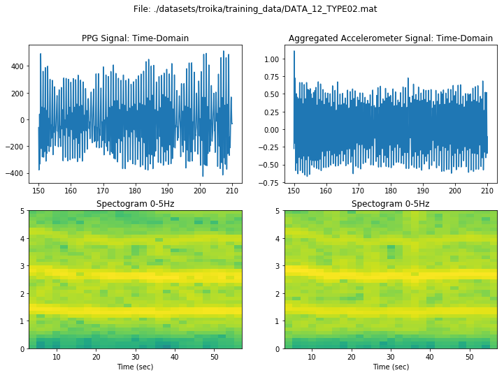

```python
plot_signals(filename, fs, window_time=(150,210))
```

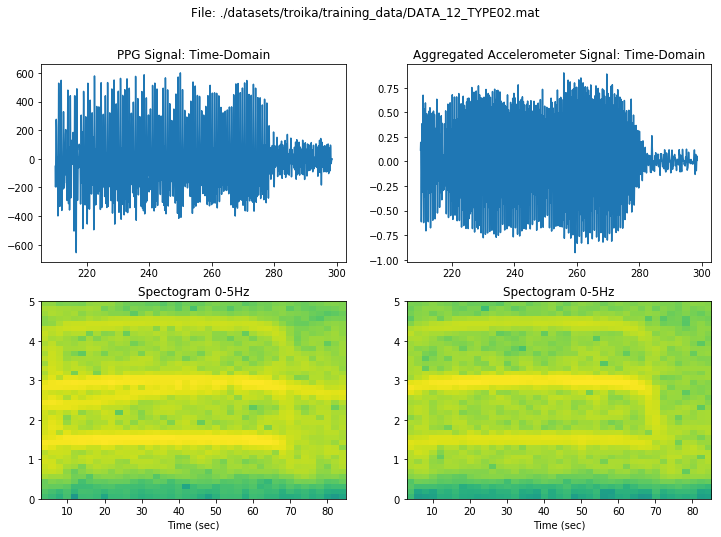

```python
plot_signals(filename, fs, window_time=(210,))
```

### Next Steps

You will now go to **Test Your Algorithm** to apply a unit test to confirm that your algorithm met the success criteria.